# microdadosBrasil

novembro de 2016

## Agenda

- Dificuldades para importar microdados
- microdadosBrasil: overview
- Princípios
  - Separação: código x metadados
- microdadosBrasil: Estrutura
  - CSV com Metadados
  - Função principal: `read_data`
  - Wrapper functions
  - Funções auxiliares

## Agenda

- Criando novas bases no `microdadosBrasil`
- Comparação com outros pacotes
- Próximos passos

## Refências inciciais

```r
# github.com/lucasmation/microdadosBrasil

# README_PT.md : documentação em português

# Instalação:

devtools::install_github("lucasmation/microdadosBrasil")
```

## Dificuldades para importar microdados

[figure not shown]

## Dificuldades para importar microdados

- Encontrar versão oficial
- Txt colunado( fixed width files)
  - Planilha com Dicionários
  - Programa de leitura: SAS e SPSS
- Falta de harmonização entre os anos
  - Nomes de arquivo
  - Nomes de variavel
  - Ex: INSTITUICAO_SUP_97.txt, ies_superior_98.txt
- Dados grandes subdivididos em muitos arquivos
  - Ex. RAIS: AC2014.txt,AL2014.txt, AM2014.txt,…

## Método tradicional de importação de microdados

### 1. Baixar os dados do site oficial

[figure not shown]

## Método tradicional de importação de microdados

### 2. Encontrar entre os arquivos as larguras de importação

[figure not shown]

## Método tradicional de importação de microdados

### 2. Encontrar entre os arquivos as larguras de importação

```r
vars_width <-

  c(4,8,3,2,1,2,2,4,3,1,1,1,1,1,1,2,1,1,1,1,1,1,1,1,1,2,1,1,1,1,1,1,
1,1,2,2,1,1,1,1,1,1,1,1,1,1,1,1,2,1,1,1,1,2,1,1,1,1,1,1,1,1,1,1,
1,1,1,4,5,1,4,5,1,1,12,1,12,1,1,2,1,2,1,1,1,1,1,1,4,5,2,1,1,1,1,1,
1,1,11,7,1,11,7,1,11,7,1,1,1,1,1,11,7,1,11,7,1,11,7,1,1,1,1,1,1,1,1,1,
1,1,1,1,1,1,1,1,1,1,1,1,1,1,1,1,1,1,1,1,1,1,1,1,12,1,12,1,1,1,1,1,
1,1,1,2,1,1,2,2,1,1,2,1,1,1,1,1,1,4,5,2,1,1,1,1,1,1,1,1,1,1,1,1,
2,2,1,1,1,2,4,5,1,1,1,1,1,1,1,12,1,12,1,1,1,2,1,12,1,12,1,1,1,1,2,1,
1,1,2,2,4,5,1,1,1,1,1,1,1,1,1,1,2,1,1,1,2,12,2,12,2,12,2,12,2,12,2,12,
2,12,2,12,1,1,2,2,2,2,1,1,2,2,1,1,1,2,4,1,1,2,2,1,1,1,2,2,2,1,1,2
,1,1,2,2,1,1,1,1,2,2,2,12,12,12,12,12,2,2,1,1,5,5,1,1,1,2,12,2,1,1,1,1
,1,12,8)
```

## Método tradicional de importação de microdados

### 3. Encontrar os nomes de pastas e arquivos

```r
data_path<- paste0("C:/Users/Nícolas/Documents/",
                    "PNAD_reponderado_2011_20150814/2011/Dados")
```

## Método tradicional de importação de microdados

### 4. Encontrar os nomes das variáveis

```r
vars<- c("V0101","V0102","V0103","V0301","V0302","V3031","V3032","V3033","V8005","V0401",
"V0402","V0403","V0404","V0405","V0406","V0407","V0408","V0409","V0410","V4111",
"V4112","V4011","v0412","V0501","V0502","V5030","V0504","V0505","V5061","V5062",
"V5063","V5064","V5065","V0507","V5080","V5090","V0510","V0511","V5121","V5122",
"V5123","V5124","V5125","V5126","V0601","V0602","V6002","V6020","V6003","V6030",
"V0604","V0605","V0606","V6007","V6070","V0608","V0609","V0610","V0611","V06111",
"V06112" "V0612","V0701","V0702","V0703","V0704","V0705","V7060","V7070","V0708",
"V7090","V7100","V0711","V7121","V7122","V7124","V7125","V7127","V7128","V0713",
"V0714","V0715","V0716","V9001","V9002","V9003","V9004","V9005","V9906","V9907",
"V9008","V9009","V9010","V9011","V9012","V9013","V9014","V9151","V9152","V9154",
"V9156","V9157","V9159","V9161","V9162","V9164","V9016","V9017","V9018","V9019",
 "V9201","V9202","V9204","V9206","V9207","V9209","V9211","V9212","V9214","V9021",
 "V9022","V9023","V9024","V9025","V9026","V9027","V9028","V9029","V9030","V9031",
 "V9032","V9033","V9034","V9035","V9036","V9037","V9038","V9039","V9040","V9041",
 "V9042","V9043","V9044","V9045","V9046","V9047","V9048","V9049","V9050","V9051",
 "V9052","V9531","V9532","V9534","V9535","V9537","V90531","V90532","V90533","V9054",
 "V9055","V9056","V9057","V9058","V9059","V9060","V9611","V9612","V9062","V9063",
 "V9064","V9065","V9066","V9067","V9068","V9069","V9070","V9971","V9972","V9073",
 "V9074","V9075","V9076","V9077","V9078","V9079","V9080","V9081","V9082","V9083",
 "V9084","V9085","V9861","V9862","V9087","V9088","V9891","V9892","V9990","V9991",
 "V9092","V9093","V9094","V9095","V9096","V9097","V9981","V9982","V9984","V9985",
 "V9987","V9099","V9100","V9101","V1021","V1022","V1024","V1025","V1027","V1028",
 "V9103","V9104","V9105","V9106","V9107","V9108","V1091","V1092","V9910","V9911",
 "V9112","V9113","V9114","V9115","V9116","V9117","V9118","V9119","V9120","V9121",
 "V9921","V9122","V9123","V9124","V1251","V1252","V1254","V1255","V1257","V1258",
 "V1260","V1261","V1263","V1264","V1266","V1267","V1269","V1270","V1272","V1273",
 "V9126","V1101","V1141","V1142","V1151","V1152","V1153","V1154","V1161","V1162",
 "V1163","V1164","V1107","V1181","V1182","V1109","V1110","V1111","V1112","V1113",
 "V1114","v1115","V4801","V4802","V4803","V4704","V4805","V4706","V4707","V4808",
 "V4809","V4810","V4711","V4812","V4713","V4814","V4715","V4816","V4817","V4718",
 "V4719","V4720","V4721","V4722","V4723","V4724","V4727","V4728","V4729","V4732",
 "V4735","V4838","V6502","V4741","V4742","V4743","V4745","V4746","V4747","V4748",
 "V4749","V4750","V9993")
```

## Método tradicional de importação de microdados

### 5. Importar no R

```r
d<- read.fwf(file = paste0(data_path, "PES2011.txt"),
                           widths = vars_width,
                            col.names = vars)
```

## Dificuldades para importar microdados

- E se quiseramos importar dados de um período diferente?
- Começe do passo 1 novamente

## microdadosBrasil: overview

- A importação de microdados deveria ser fácil e simples:
- Uma função para download e outra para leitura

## microdadosBrasil: overview

### Importação da PNAD

```r
download_sourceData(dataset = "PNAD", i = 2011, unzip = T)
d<- read_PNAD(ft = "pessoas", i = 2011)
```

## microdadosBrasil: overview

### Importação da base de escolas do Censo Escolar

```r
download_sourceData(dataset = "CensoEscolar", i = 2000, unzip = T)
d<- read_CensoEscolar(ft = "escola", i = 2000)
```

## Separação: código x metadados

### Hadley Wickham, mai/2016, Managing many models with R

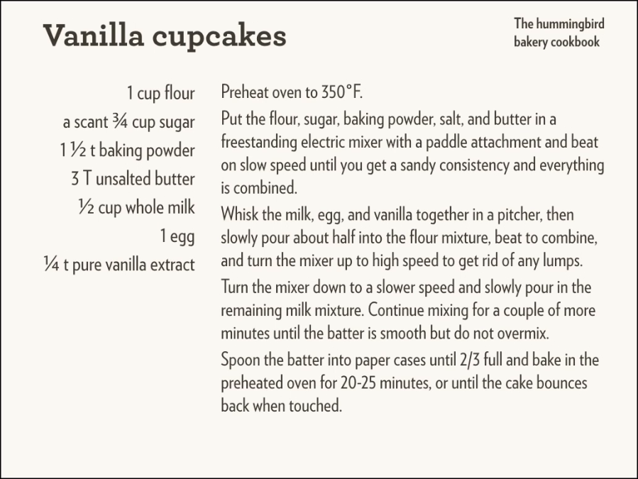

## Separação: código x metadados

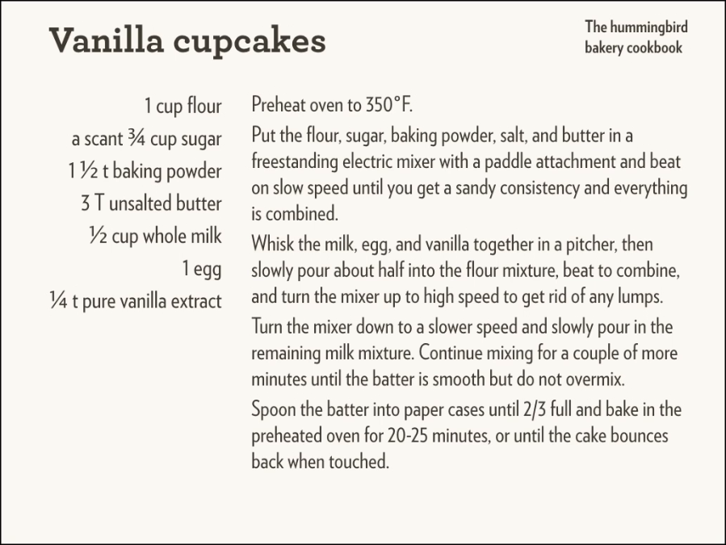

## Separação: código x metadados

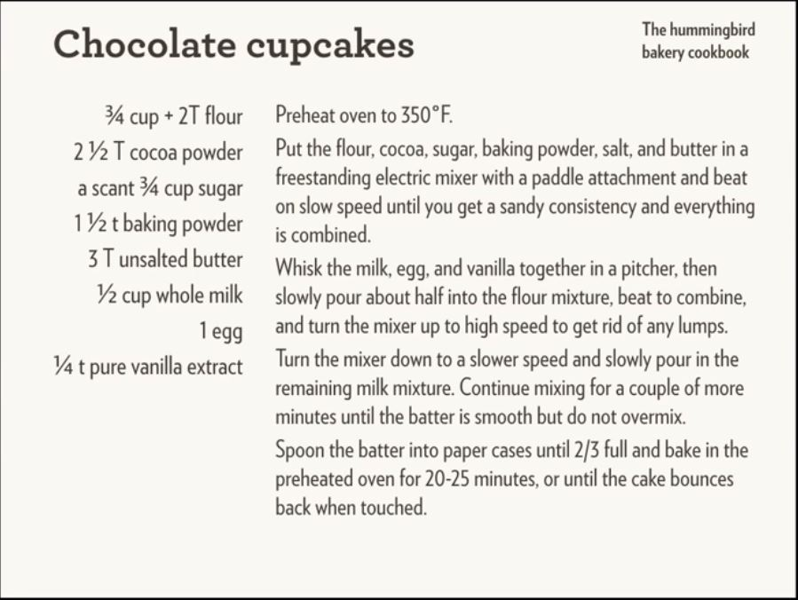

## Separação: código x metadados

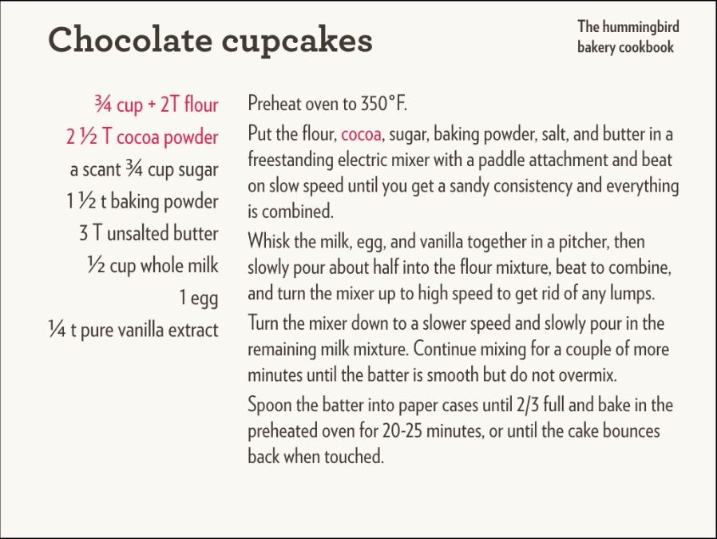

## Separação: código x metadados

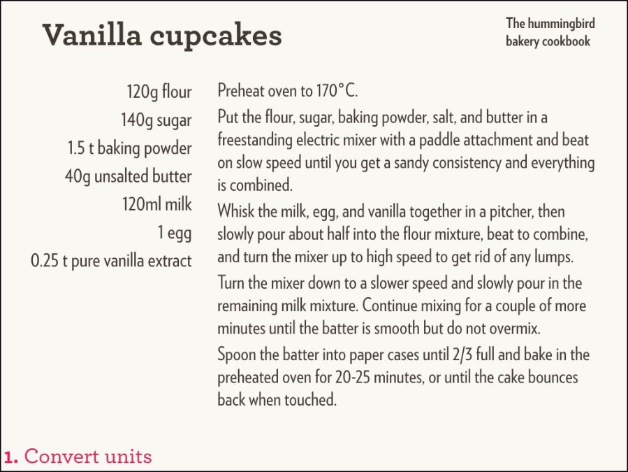

## Separação: código x metadados

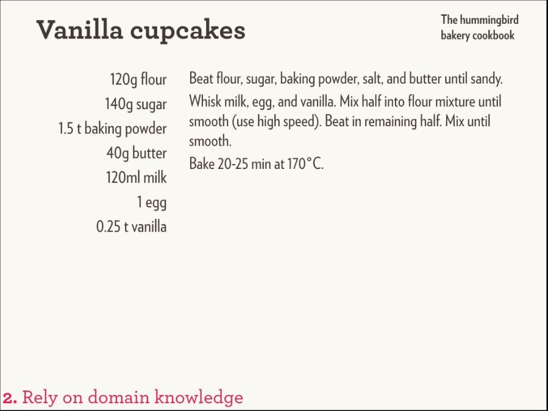

## Separaçãoo: código x metadados

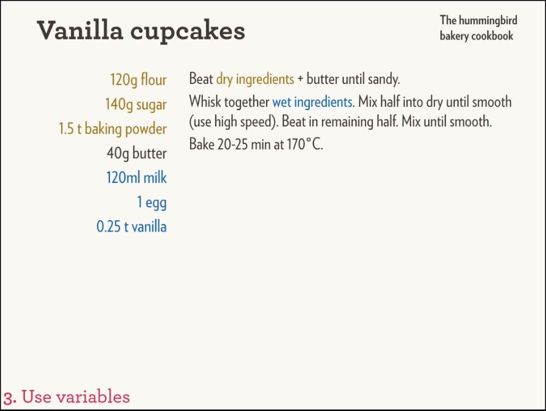

## Separação: código x metadados

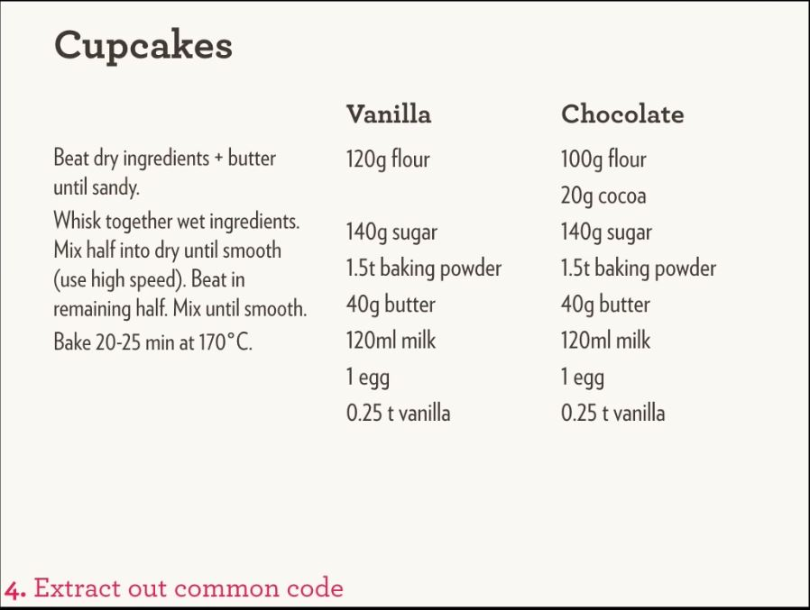

## Separação: código x metadados

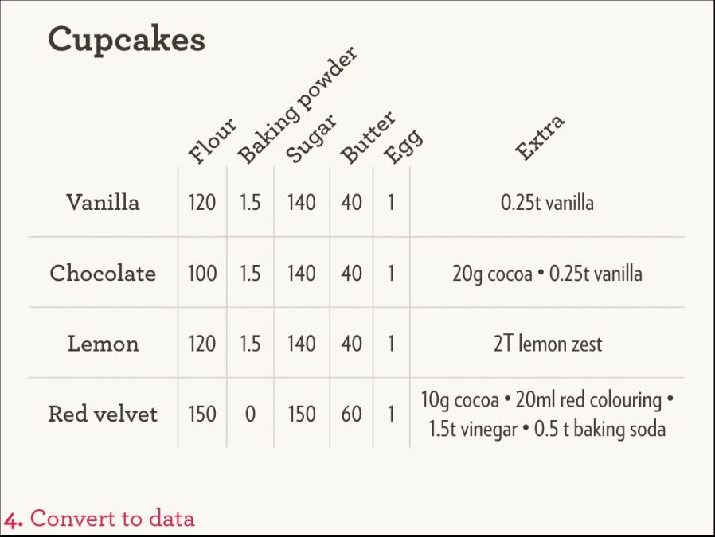